Return To Home Page

# Module 2

### Solved Example of Self Organizing Maps: Iris Dataset

In this module we will apply our knowledge from module 1 and implement SOM for dimensionality reduction for the Iris dataset [1].

# Table of Contents

- Part 1: Loading and installing necessary libraries.
- Part 2: Creation of functions.
- Part 3: Loading the data and necessary files for implementation.
- Part 4: Generating the Self Organizing Map.
- Part 5: Visualizing the results.
- Part 6: References

## Part 1: Loading necessary libraries.

```r
# 1.1) Loading the necessary libraries.
library(dplyr)
library(photobiology)
library(ggplot2)
```

## Part 2: Creation of functions.

```r
#-----------------------------------------------------------------------------------------------------------------------------------------------------------------

# 2.1) A function to return the sum of squared distance between "x" and "y".

euclidean_distance <- function(x, y) {
  ret <- sqrt(sum((x - y)^2))
  return(ret)
}

#-----------------------------------------------------------------------------------------------------------------------------------------------------------------

# 2.2) Function to create a SOM grid.
# "x*y" is the number of neurons.
# "p" is the number of columns in the original data frame or number of input dimensions.

create_grid <- function(x,y,p) {
  ret <- matrix(data = rnorm(x * y * p), nrow = x * y, ncol = p)
  return(ret)
}


#-----------------------------------------------------------------------------------------------------------------------------------------------------------------

# 2.3) Function to decay the radius exponentially over time.
# "radius" is the initial radius that is passed.
# "current_iteration" represents the current iteration.
# "time_constant" is the time constant.

decay_radius_function <- function(radius, current_iteration, time_constant) {
  ret <- radius * exp(-current_iteration / time_constant)
  return(ret)
}

#-----------------------------------------------------------------------------------------------------------------------------------------------------------------

# 2.4) Function to decay the learning rate.
# "learning_rate" is the current learning rate.
# "current_iteration" is the current iteration.
# "n_iteration" is the number of iterations.

decay_learning_rate <- function(learning_rate, current_iteration, n_iteration) {
  ret <- learning_rate * exp(-current_iteration / n_iteration)
  return(ret)
}

#-----------------------------------------------------------------------------------------------------------------------------------------------------------------

# 2.5) A function to calculate influence over neighbouring neurons.
# "distance" is the lateral distance.
# "radius" is the current neighbourhood radius.

influence_calculation <- function(distance, radius) {
  ret <- exp(-(distance^2) / (2 * (radius^2)))
  return(ret)
}


#-----------------------------------------------------------------------------------------------------------------------------------------------------------------

# 2.6) A function to return the winning neuron.
# "x" is a single row of data and "input_grid" is the grid.

BMU <- function(x, input_grid) {
  distance <- 0
  min_distance <- 10000000
  min_ind <- -1
  for (e in 1:nrow(input_grid)) # Iterating through grid
  {
    distance <- euclidean_distance(x, input_grid[e, ]) # Calculating euclidean_distance distance.
    if (distance < min_distance) {
      min_distance <- distance # Updating min distance for winning unit.
      min_ind <- e # Updating winning neuron.
    }
  }
  return(min_ind-1) # Returns index of BMU.
}

#-----------------------------------------------------------------------------------------------------------------------------------------------------------------

# 2.7) Fastest BMU Implementation.


BMU_Vectorised <- function(x, input_grid) {
  dist_mtrx=rowSums(sweep(input_grid,2,x)^2) # Calculating the distance of this row from all the neurons using matrix operations.
  min_ind=which.min(dist_mtrx) # Finding the location of the neuron with the minimum distance.
  return (min_ind-1) # Returning the zero-indexed value of the winning neuron.
}


#-----------------------------------------------------------------------------------------------------------------------------------------------------------------

# 2.8) A function to encapsulate the entire creation, working and updating of SOM over the training period.
# "x" is the input and "input_grid" is the SOM grid that will be updated in each iteration.

SOM <- function(x, input_grid) {
  breaker <- 0
  n_iteration <- nrow(x) # Defining number of iterations.
  initial_learning_rate <- 0.5 # Defining initial learning rate.
  initial_radius <- 15 # Defining initial radius.
  time_constant <- n_iteration / log(initial_radius) # Initializing time constant.
  lateral_distance_points=expand.grid(1:sqrt(nrow(input_grid)),1:sqrt(nrow(input_grid)))# Initializing physical locations of neurons to figure out lateral distance.
  rows=sqrt(nrow(input_grid)) # Taking the number of rows as square root of the number of entries in the grid.
  n_epochs=40 # Defining the number of epochs.
  new_radius <- initial_radius
  l <- c()
  for(ne in 1:n_epochs)
  {
    extra <- ((ne-1)*400)
    for (i in 1:n_iteration) # Looping through for training.
    {
      old_grid=input_grid
      curr_i <- extra + i
      sample_input_row <- as.vector(unlist(x[sample(1:nrow(x), size = 1, replace = F), ])) # Selecting random input row from given data set.
      new_radius <- decay_radius_function(initial_radius, curr_i, time_constant) # Decaying the radius.
      new_learning_rate <- decay_learning_rate(initial_learning_rate,curr_i, n_iteration) # Decaying the learning rate.
      index_temp <- BMU_Vectorised(sample_input_row, input_grid) # Finding best matching unit for given input row.
      index_new=c((as.integer(index_temp/rows)+1),(index_temp%%rows)+1) # Converting a 1D co-ordinate to a 2D co-ordinate for finding lateral distance on the map.
      lateral_distance=sqrt(abs(rowSums(sweep(lateral_distance_points,2,index_new)^2))) # Finding Euclidean distance between the given best matching units and all units on the map.
      rn=which(lateral_distance<=new_radius) # Finding neurons that are within the radius of the winning unit.
      inf=influence_calculation(lateral_distance[rn],new_radius) # Calculating the influence of the winning neuron on neighbours.
      if(length(rn)!=1) # Updating multiple rows if neighbourhood is large.
      {
        # Calculating the influence of the winning neuron on neighbours.
        diff_grid=(sweep(input_grid[rn,],2,sample_input_row))*-1 # A temporary matrix that stores the difference between the data point and the weights of the winning neuron & neighbours.
        updated_weights=new_learning_rate*inf*diff_grid # The updating operation on the winning and neighbouring neurons.
        input_grid[rn,]=input_grid[rn,]+updated_weights # Now updating those grid entries that are either the winning neuron or its neighbours.
      }
      else # Updating only winning neuron.
      {
        diff_row=(input_grid[rn,]-sample_input_row)*-1 # A temporary matrix that stores the difference between the data point and the weights of the winning neuron & neighbours.
        updated_weights=new_learning_rate*inf*diff_row # The updating operation on the winning and neighbouring neurons.
        input_grid[rn,]=input_grid[rn,]+updated_weights # Now updating those grid entries that are either the winning neuron or its neighbours.
      }
      l <- c(l,euclidean_distance(old_grid,input_grid))
      if(isTRUE(all.equal(old_grid,input_grid)))
      {
        breaker <- 1
        break
      }
    }
    if(breaker ==1)
    {
      break
    }
  }
  return(list(input_grid,l)) # Returning the updated SOM weights.
}
```

## Part 3: Loading the data files for implementation.

```r
# 3.1) Reading the data and scaling it.
data<-scale(iris[,-5])
X <- scale(data[, ])
data <- X

# 3.2) Setting the seed to obtain reproducible results.
set.seed(222)

# 3.3) Creating the grid of neurons.
grid <- create_grid(5,5,4)
```

## Part 4: Generating the Self Organizing Map.

```r
# 4.1) Generating the SOM.
y <- SOM(data,grid)

# 4.2) Transforming the SOM weights to usable form.
gridSOM <- y[1]
gridSOM
```

```
## [[1]]
##              [,1]        [,2]       [,3]        [,4]
##  [1,]  1.51979580  0.03237630  1.2644454  1.14230472
##  [2,]  1.24099155 -0.02410680  1.0516778  0.98407574
##  [3,]  0.73293736 -0.29868812  0.7240412  0.60851629
##  [4,]  0.15410923 -0.77490850  0.4535389  0.34719100
##  [5,]  0.01098373 -0.59608748  0.4244492  0.37848457
##  [6,]  1.20915449 -0.09180618  1.0353214  1.03089388
##  [7,]  1.02275478 -0.05746048  0.8055906  0.72338924
##  [8,]  0.63555127 -0.35351906  0.4973977  0.33937501
##  [9,]  0.22881853 -0.72438396  0.2992720  0.11486734
## [10,] -0.19835820 -0.62107698  0.1771841  0.09836969
## [11,]  0.68795681 -0.41771178  0.7460912  0.66425283
## [12,]  0.66586054 -0.34578508  0.5388258  0.37420532
## [13,]  0.26071271 -0.24531347  0.1953997  0.07510772
## [14,] -0.77764817 -0.06289039 -0.7263837 -0.73873748
## [15,] -0.62067355  0.19287913 -0.5233841 -0.56000999
## [16,]  0.20381249 -0.78914720  0.4569668  0.30244892
## [17,]  0.19980266 -0.75748213  0.3117550  0.10648900
## [18,] -0.71927940 -0.11619778 -0.7058482 -0.68951213
## [19,] -1.15931006  0.45744592 -1.2669385 -1.21821706
## [20,] -0.99092608  1.00557473 -1.2819808 -1.20593553
## [21,]  0.09036951 -0.67733186  0.4509914  0.32609800
## [22,] -0.19596576 -0.61017007  0.1541737  0.05987712
## [23,] -0.71114901  0.33176281 -0.7535654 -0.72404885
## [24,] -0.98814935  1.01000002 -1.2860587 -1.21374472
## [25,] -0.74348052  1.75151250 -1.2995359 -1.23497618
```

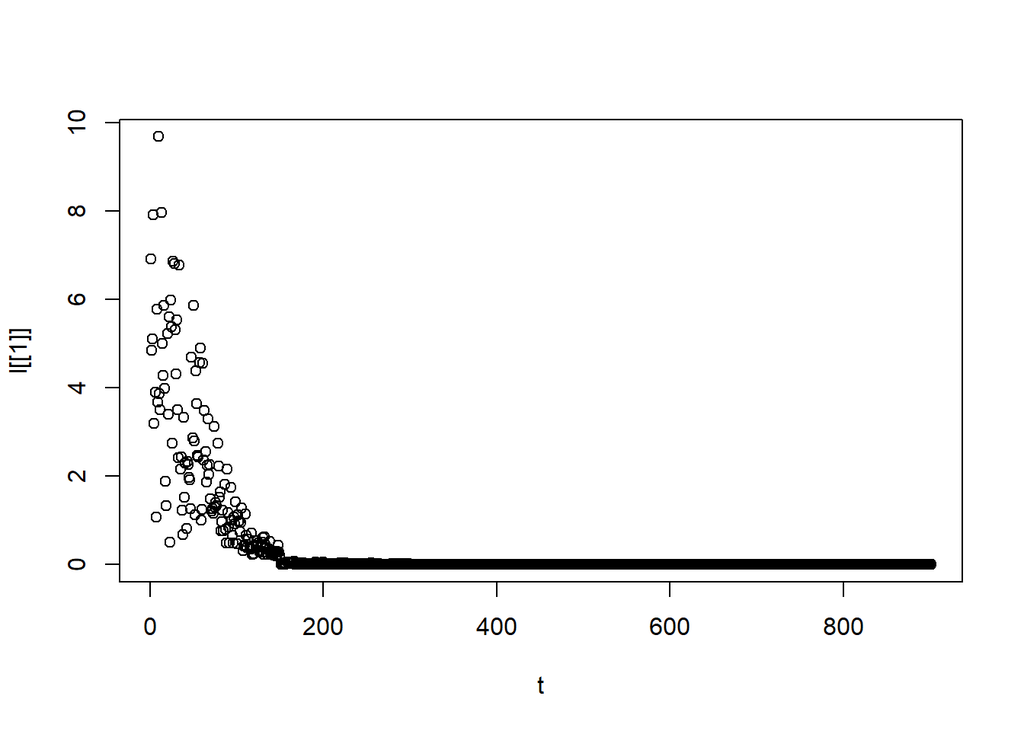

```r
l <- y[2]
t=1:length(l[[1]])
plot(t,l[[1]])
```

```r
l=unlist(l)
l[which.min(unlist(l))]
```

```
## [1] 4.591932e-08
```

The above plot shows the decay in learning rate in a visual format. The points on the graph represent the difference between the weights of the neural network in consecutive iterations of training. Thus the downwards curve represents a decay in rapidness with which the SOM updates its weights, or in visual terms adjusts itself to map the input space. As the training of the SOM progresses, the neighborhood radii decrease and the map fixates on finer details, but has learnt a majority of the representation and does not move rapidly. Initially the map has a steep curve which indicates that it is initially learning rapidly.

## Part 5: Visualizing the results.

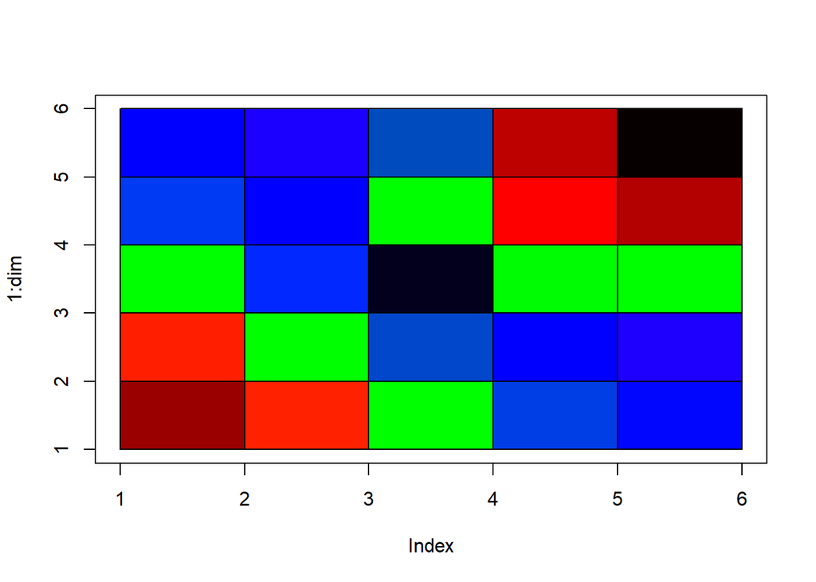

```r
# 5.1) Creating a function to visualize the SOM results by mapping the numbers to colors.
drawGrid<- function(weight,dimension){

  # Converting to a matrix.
  weight<-as.matrix(weight, ncol = ncol(weight))

  norm.matrix<-NULL

  # Calculation of the "norm".
  for(i in 1:length(weight[,1])){
    a<-norm(weight[i,], type = "2")
    norm.matrix<-rbind(norm.matrix,a)
  }

  # Mapping to range 400 to 700.
  input_start<-min(norm.matrix)
  input_end<-max(norm.matrix)
  output_start<-400
  output_end<-700


  # Calculating wavelength based on "norm".
  color<-NULL
  for(i in 1:length(norm.matrix)){
    input = norm.matrix[i]
    output = output_start + ((output_end - output_start) / (input_end - input_start)) * (input - input_start)
    color<-rbind(color,output)
  }

  # Getting the colors (hex values) from the wavelength.
  color.rgb<-w_length2rgb(color)


  # Plotting the grid.
  dim<-max(dimension)+1
  plot(1:dim, type = "n")

  for (i in 1:dimension[1]) {
    for(j in 1:dimension[2]){
      rect(i,j,i+1,j+1, col = color.rgb[i*dimension[1]+j - dimension[1]])
    }
  }
}

# 5.2) Plotting  the grid of weights.
gridSOM=matrix(unlist(gridSOM),ncol=4)
drawGrid(gridSOM,c(5,5))
```

## Conclusion

Thus we have successfully implemented Self Organizing Maps in R for dimensionality reduction using the Iris data set [1]. Using the grid we can see that there are predominantly 3 colors or clusters [green, blue and red] produced by the SOM, which correspond to the 3 original clusters Iris Setosa, Iris Versicolor and Iris Virginica of the Iris data set [1]. We experimented extensively with the size of the neuron grid, number of cells in visualization grid and the learning rate, but obtained the best results with the parameters specified in this code. Effective visualization is an important challenge of the SOM implementation as the weights needs to be expressed effectively to show the inherent groups or clusters in the data.

## Part 6: References

[1]

Iris Dataset. https://archive.ics.uci.edu/ml/datasets/iris.